# HOMEWORK 2

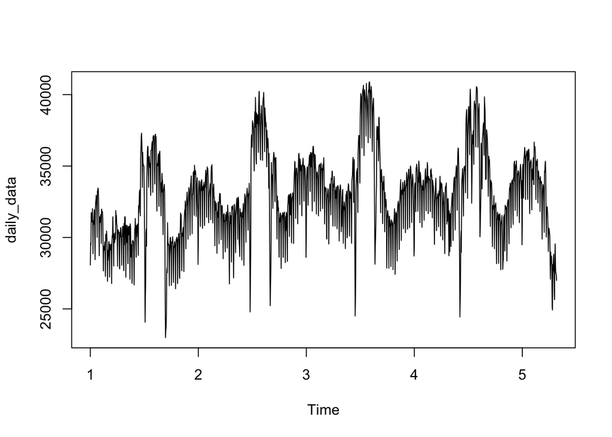

```r
plot(daily_data)
```

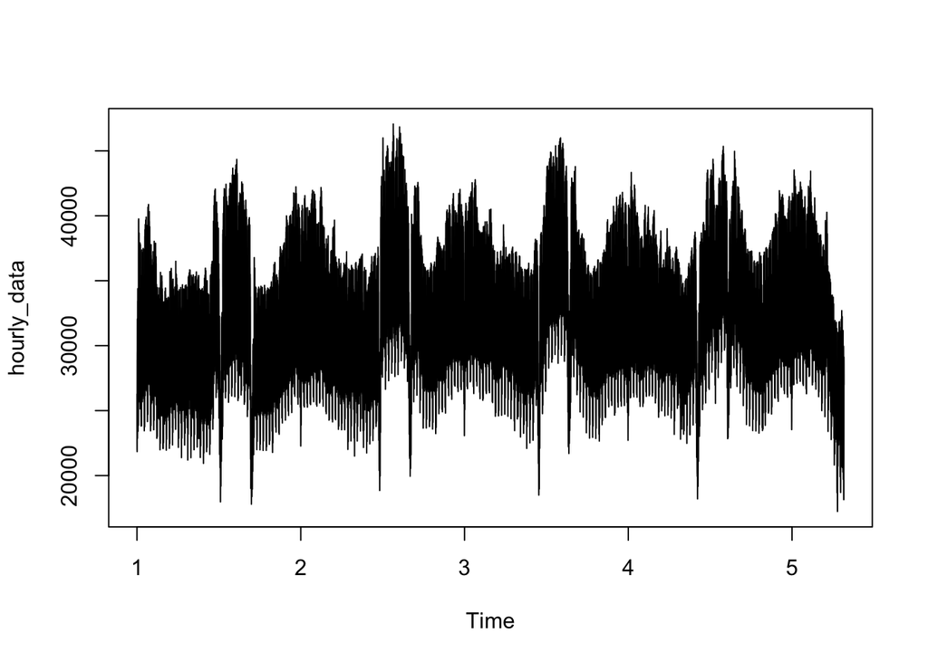

```r
plot(hourly_data)
```

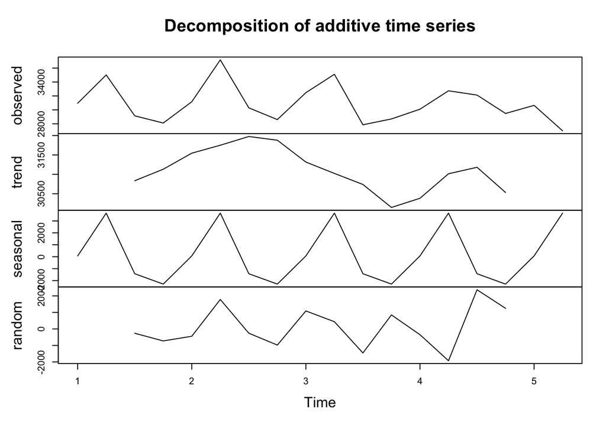

```r
dec_quart<-decompose(quarterly_data, type = "additive")
dec_mont<-decompose(monthly_data, type = "additive")
dec_week<-decompose(weekly_data, type = "additive")
dec_daily<-decompose(daily_data, type = "additive")
dec_hour<-decompose(hourly_data, type = "additive")
plot(dec_quart)
```

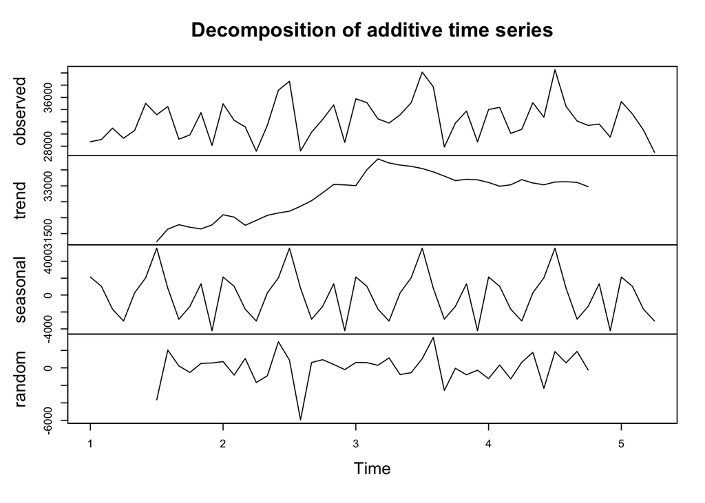

```r
plot(dec_mont)
```

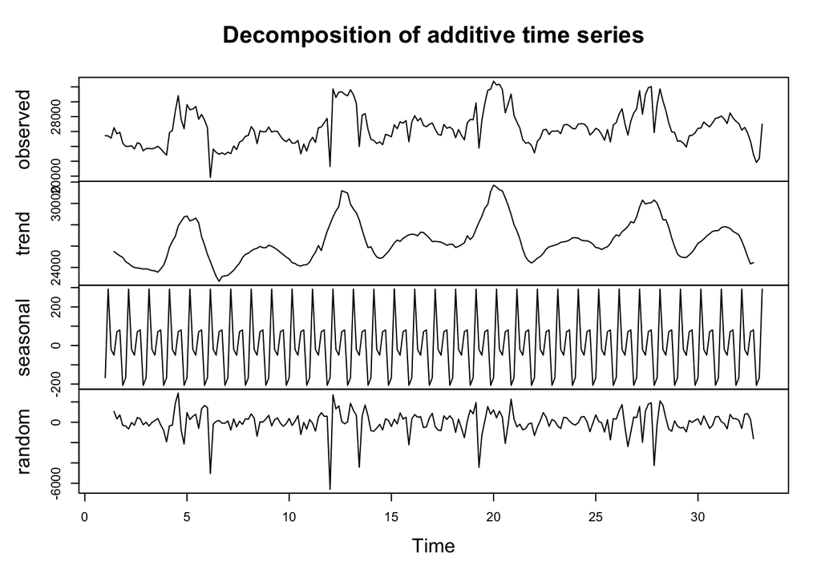

```r
plot(dec_week)
```

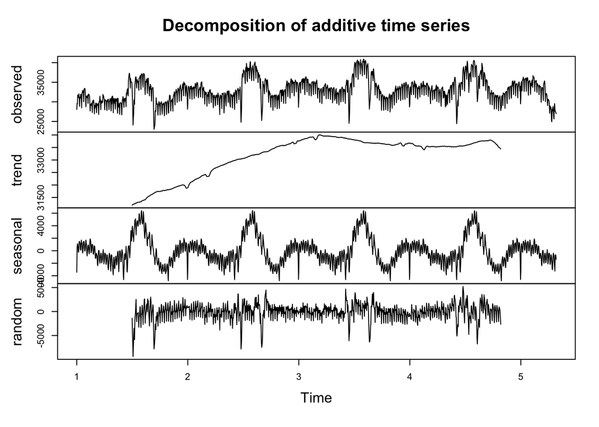

```r
plot(dec_daily)
```

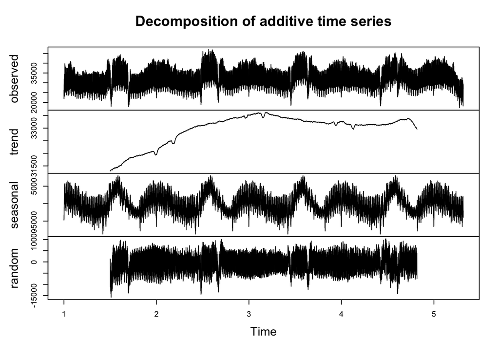

```r
plot(dec_hour)
```

At this part, I have converted the xts type data into ts type data to examine the data more clearly and decompose them. After I decomposed the data, I’ve plotted the decomposed versions.

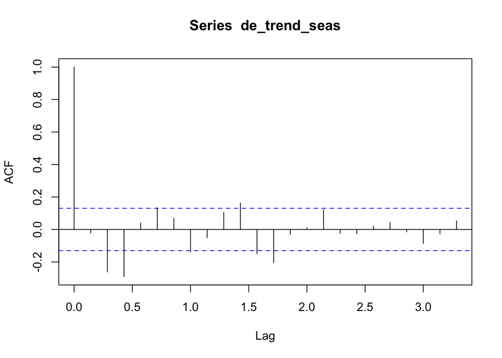

```r
deseasonilized <- weekly_data - dec_week$seasonal
de_trend_seas <- deseasonilized - dec_week$trend
acf(de_trend_seas, na.action = na.pass)
```

```r
#install.packages("forecast")
require(forecast)
ma_model_1 <- arima(de_trend_seas, order = c(0,0,1))
print(ma_model_1)
```

```
##
## Call:
## arima(x = de_trend_seas, order = c(0, 0, 1))
##
## Coefficients:
##           ma1  intercept
##       -0.0520     7.3488
## s.e.   0.1096    73.0055
##
## sigma^2 estimated as 1304153:  log likelihood = -1861.08,  aic = 3728.17
```

```r
ma_model_2 <- arima(de_trend_seas, order = c(0,0,2))
print(ma_model_2)
```

```
##
## Call:
## arima(x = de_trend_seas, order = c(0, 0, 2))
##
## Coefficients:
##           ma1      ma2  intercept
##       -0.2930  -0.3955     4.5568
## s.e.   0.0789   0.0848    22.7946
##
## sigma^2 estimated as 1137145:  log likelihood = -1846.31,  aic = 3700.63
```

```r
ma_model_3 <- arima(de_trend_seas, order = c(0,0,3))
print(ma_model_3)
```

```
##
## Call:
## arima(x = de_trend_seas, order = c(0, 0, 3))
##
## Coefficients:
##           ma1      ma2      ma3  intercept
##       -0.2624  -0.3962  -0.3414     1.2172
## s.e.   0.0634   0.0628   0.0634     2.1399
##
## sigma^2 estimated as 970130:  log likelihood = -1830.81,  aic = 3671.62
```

```r
ma_model_4 <- arima(de_trend_seas, order = c(0,0,4))
print(ma_model_4)
```

```
##
## Call:
## arima(x = de_trend_seas, order = c(0, 0, 4))
##
## Coefficients:
##           ma1      ma2      ma3      ma4  intercept
##       -0.2571  -0.3908  -0.3390  -0.0131     1.2196
## s.e.   0.0693   0.0679   0.0646   0.0668     2.1691
##
## sigma^2 estimated as 970072:  log likelihood = -1830.79,  aic = 3673.58
```

At this part, I first detrended and deseasonalized the weekly data and tried 4 ma models. The best one turned out to be the ma_model_3 with the lowest AIC value.

```r
ar_model_1 <- arima(de_trend_seas, order = c(1,0,0))
print(ar_model_1)
```

```
##
## Call:
## arima(x = de_trend_seas, order = c(1, 0, 0))
##
## Coefficients:
##           ar1  intercept
##       -0.0221     7.2628
## s.e.   0.0677    75.3590
##
## sigma^2 estimated as 1304970:  log likelihood = -1861.15,  aic = 3728.31
```

```r
ar_model_2 <- arima(de_trend_seas, order = c(2,0,0))
print(ar_model_2)
```

```
##
## Call:
## arima(x = de_trend_seas, order = c(2, 0, 0))
##
## Coefficients:
##           ar1      ar2  intercept
##       -0.0278  -0.2640     7.2726
## s.e.   0.0654   0.0651    57.6080
##
## sigma^2 estimated as 1213610:  log likelihood = -1853.24,  aic = 3714.48
```

```r
ar_model_3 <- arima(de_trend_seas, order = c(3,0,0))
print(ar_model_3)
```

```
##
## Call:
## arima(x = de_trend_seas, order = c(3, 0, 0))
##
## Coefficients:
##           ar1      ar2      ar3  intercept
##       -0.1154  -0.2736  -0.3282     5.9371
## s.e.   0.0640   0.0615   0.0637    41.0160
##
## sigma^2 estimated as 1081745:  log likelihood = -1840.76,  aic = 3691.52
```

```r
ar_model_4 <- arima(de_trend_seas, order = c(4,0,0))
print(ar_model_4)
```

```
##
## Call:
## arima(x = de_trend_seas, order = c(4, 0, 0))
##
## Coefficients:
##           ar1      ar2      ar3      ar4  intercept
##       -0.1448  -0.2982  -0.3387  -0.0889     5.8160
## s.e.   0.0675   0.0640   0.0639   0.0672    37.5302
##
## sigma^2 estimated as 1073037:  log likelihood = -1839.89,  aic = 3691.77
```

At this part, I tried 4 ar models. The best one turned out to be the ar_model_3 with the lowest AIC value.

```r
AIC(ar_model_3)
```

```
## [1] 3691.519
```

```r
BIC(ar_model_3)
```

```
## [1] 3708.487
```

```r
AIC(ma_model_3)
```

```
## [1] 3671.622
```

```r
BIC(ma_model_3)
```

```
## [1] 3688.59
```

It turns out that ma_model_3 is better than the ar_model_3. Now it is time to make forecasts with this model.

```r
model_forecast <- predict(ma_model_3, n.ahead = 1)$pred
model_forecast_se <- predict(ma_model_3, n.ahead = 1)$se
```